# week7pd-start

**css link**

go to the cell to see

```python
import numpy as np
import pandas as pd
```

```python
data = pd.read_csv('./data/data_covid_cases_deaths.csv')
```

```python
type(data)
```

```
pandas.core.frame.DataFrame
```

```python
print(data)
```

```
             date  number of daily cases  number of daily deaths
0    Feb 15  2020                      0                       0
1    Feb 16  2020                      0                       0
2    Feb 17  2020                      0                       0
3    Feb 18  2020                      0                       0
4    Feb 19  2020                      0                       0
..            ...                    ...                     ...
776  Apr 01  2022                 148629                     134
777  Apr 02  2022                 132114                      68
778  Apr 03  2022                 102266                      31
779  Apr 04  2022                  27648                     149
780  Apr 05  2022                 203021                     129

[781 rows x 3 columns]
```

## DataFrame as a table

As you can see from the result above, the DataFrame is like a table with rows and columns.

## Locate Row

Pandas use the `loc` attribute to return one or more specified row(s)

```python
print(data.loc[0])
```

```
date                      Feb 15  2020
number of daily cases                0
number of daily deaths               0
Name: 0, dtype: object
```

```python
row = data.loc[0]
print(type(row))
```

```
<class 'pandas.core.series.Series'>
```

## Series (table rows) are limilar to lists

```python
len(row)
```

```
3
```

```python
row[0]
```

```
'Feb 15  2020'
```

```python
for r in row:
    print(r)
```

```
Feb 15  2020
0
0
```

```python
data_part = data.loc[[0, 1]]
print(type(data_part))
```

```
<class 'pandas.core.frame.DataFrame'>
```

**Characterize class to which `data_part` belongs**

* The same as the initial variable (= table) `data`

```python
data.loc[[0, 1]].loc[0]
```

```
date                      Feb 15  2020
number of daily cases                0
number of daily deaths               0
Name: 0, dtype: object
```

```python
data.loc[[1, 2]]
```

|  | date | number of daily cases | number of daily deaths |
| --- | --- | --- | --- |
| 1 | Feb 16 2020 | 0 | 0 |
| 2 | Feb 17 2020 | 0 | 0 |

```python
data.loc[[1, 2]].loc[1]
```

```
date                      Feb 16  2020
number of daily cases                0
number of daily deaths               0
Name: 1, dtype: object
```

- How many entries are there in the first row?
- What is the table element in row 5, column 1 (let us count from $0$)?

```python
# write your code
```

- What is written in the first column of the output of

  ```
  data.loc[0]
  ```

- The names of each column.
- You can refer to columns by name

  ```
  data['number of daily cases']
  ```

```python
data['number of daily cases']
```

```
0           0
1           0
2           0
3           0
4           0
        ...
776    148629
777    132114
778    102266
779     27648
780    203021
Name: number of daily cases, Length: 781, dtype: int64
```

```python
len(data['number of daily cases'])
```

```
781
```

```python
type(data['number of daily cases'])
```

```
pandas.core.series.Series
```

**Recall when we dealt with the type `data['number of daily cases']`**

* The same as rows, f.e., `data.loc[0]`

## Headers

The `head()` method returns the headers and a specified number of rows, starting from the top.

```python
data.head(3)
```

|  | date | number of daily cases | number of daily deaths |
| --- | --- | --- | --- |
| 0 | Feb 15 2020 | 0 | 0 |
| 1 | Feb 16 2020 | 0 | 0 |
| 2 | Feb 17 2020 | 0 | 0 |

This method allows to have a look at the data

There is also a `tail()` method for viewing the last rows of the DataFrame.

The `tail()` method returns the headers and a specified number of rows, starting from the bottom.

```python
data.tail()
```

|  | date | number of daily cases | number of daily deaths |
| --- | --- | --- | --- |
| 776 | Apr 01 2022 | 148629 | 134 |
| 777 | Apr 02 2022 | 132114 | 68 |
| 778 | Apr 03 2022 | 102266 | 31 |
| 779 | Apr 04 2022 | 27648 | 149 |
| 780 | Apr 05 2022 | 203021 | 129 |

## Info About the Data

The DataFrames object has a method called `info()`, that gives you more information about the data set.

```python
data.info()
```

```
<class 'pandas.core.frame.DataFrame'>
RangeIndex: 781 entries, 0 to 780
Data columns (total 3 columns):
 #   Column                  Non-Null Count  Dtype
---  ------                  --------------  -----
 0   date                    781 non-null    object
 1   number of daily cases   781 non-null    int64
 2   number of daily deaths  781 non-null    int64
dtypes: int64(2), object(1)
memory usage: 18.4+ KB
```

### Explanation

You see the number of non-null elements in each column

### Number of unique data

```python
data['number of daily cases'].nunique()
```

```
760
```

## Data Cleaning

- Data cleaning means fixing bad data in your data set.
- Bad data could be:
  - Empty cells
  - Data in wrong format
  - Wrong data
  - Duplicates

### Spoiling of the table

```python
data['number of daily cases'][2]
```

```
0
```

```python
(data.loc[2])[0]
```

```
'Feb 17  2020'
```

```python
data.loc[2]
```

```
date                      Feb 17  2020
number of daily cases                0
number of daily deaths               0
Name: 2, dtype: object
```

```python
#Setting values by label:
data.iat[2, 1] = 1
```

```python
data.loc[2]
```

```
date                      Feb 17  2020
number of daily cases                1
number of daily deaths               0
Name: 2, dtype: object
```

```python
data.at[2, "number of daily cases"] = 2
data.loc[2]
```

```
date                      Feb 17  2020
number of daily cases                2
number of daily deaths               0
Name: 2, dtype: object
```

## Sorting

### by axis

```python
data.sort_index(axis=1, ascending=False)
```

|  | number of daily deaths | number of daily cases | date |
| --- | --- | --- | --- |
| 0 | 0 | 0 | Feb 15 2020 |
| 1 | 0 | 0 | Feb 16 2020 |
| 2 | 0 | 0 | Feb 17 2020 |
| 3 | 0 | 0 | Feb 18 2020 |
| 4 | 0 | 0 | Feb 19 2020 |
| ... | ... | ... | ... |
| 776 | 134 | 148629 | Apr 01 2022 |
| 777 | 68 | 132114 | Apr 02 2022 |
| 778 | 31 | 102266 | Apr 03 2022 |
| 779 | 149 | 27648 | Apr 04 2022 |
| 780 | 129 | 203021 | Apr 05 2022 |

781 rows × 3 columns

```python
data.sort_index(axis=0, ascending=True)
```

|  | date | number of daily cases | number of daily deaths |
| --- | --- | --- | --- |
| 0 | Feb 15 2020 | 0 | 0 |
| 1 | Feb 16 2020 | 0 | 0 |
| 2 | Feb 17 2020 | 0 | 0 |
| 3 | Feb 18 2020 | 0 | 0 |
| 4 | Feb 19 2020 | 0 | 0 |
| ... | ... | ... | ... |
| 776 | Apr 01 2022 | 148629 | 134 |
| 777 | Apr 02 2022 | 132114 | 68 |
| 778 | Apr 03 2022 | 102266 | 31 |
| 779 | Apr 04 2022 | 27648 | 149 |
| 780 | Apr 05 2022 | 203021 | 129 |

781 rows × 3 columns

**Explanation:**  
We sorted along horizontal and vertical directions according to the title line and ID-field respectively

### By value

```python
data.sort_values(by="number of daily deaths")
```

|  | date | number of daily cases | number of daily deaths |
| --- | --- | --- | --- |
| 0 | Feb 15 2020 | 0 | 0 |
| 193 | Aug 26 2020 | 5095 | 0 |
| 201 | Sep 03 2020 | 6716 | 0 |
| 202 | Sep 04 2020 | 8423 | 0 |
| 18 | Mar 04 2020 | 67 | 0 |
| ... | ... | ... | ... |
| 48 | Apr 03 2020 | 4755 | 1119 |
| 54 | Apr 09 2020 | 3895 | 1339 |
| 47 | Apr 02 2020 | 1923 | 1354 |
| 52 | Apr 07 2020 | 3432 | 1416 |
| 60 | Apr 15 2020 | 2393 | 1437 |

781 rows × 3 columns

```python
data.sort_values(by="number of daily deaths").sort_values(by="number of daily cases")
```

|  | date | number of daily cases | number of daily deaths |
| --- | --- | --- | --- |
| 0 | Feb 15 2020 | 0 | 0 |
| 168 | Aug 01 2020 | 0 | 3 |
| 131 | Jun 25 2020 | 0 | 21 |
| 5 | Feb 20 2020 | 0 | 0 |
| 7 | Feb 22 2020 | 0 | 0 |
| ... | ... | ... | ... |
| 705 | Jan 20 2022 | 425183 | 245 |
| 711 | Jan 26 2022 | 428008 | 258 |
| 704 | Jan 19 2022 | 436167 | 231 |
| 703 | Jan 18 2022 | 464769 | 375 |
| 710 | Jan 25 2022 | 501635 | 467 |

781 rows × 3 columns

## New column

```python
data1 = data.reindex(index=range(4), columns=list(data.columns) + ["new"])
data1
```

|  | date | number of daily cases | number of daily deaths | new |
| --- | --- | --- | --- | --- |
| 0 | Feb 15 2020 | 0 | 0 | NaN |
| 1 | Feb 16 2020 | 0 | 0 | NaN |
| 2 | Feb 17 2020 | 0 | 0 | NaN |
| 3 | Feb 18 2020 | 0 | 0 | NaN |

```python
data1.at[1, "number of daily cases"] = np.nan
data1
```

|  | date | number of daily cases | number of daily deaths | new |
| --- | --- | --- | --- | --- |
| 0 | Feb 15 2020 | 0.0 | 0 | NaN |
| 1 | Feb 16 2020 | NaN | 0 | NaN |
| 2 | Feb 17 2020 | 0.0 | 0 | NaN |
| 3 | Feb 18 2020 | 0.0 | 0 | NaN |

- Change 1st and 3d variables of the last columnt to 7 and 10 respectively

```python
# Place for your code
```

```python
data2 = data1
data2
```

[output not shown]

```python
data2.at[0, "new"] = 2
data2.at[3, "new"] = 3
data1 = data2
data1
```

|  | date | number of daily cases | number of daily deaths | new |
| --- | --- | --- | --- | --- |
| 0 | Feb 15 2020 | 0.0 | 0 | 2.0 |
| 1 | Feb 16 2020 | NaN | 0 | NaN |
| 2 | Feb 17 2020 | 2.0 | 0 | NaN |
| 3 | Feb 18 2020 | 0.0 | 0 | 3.0 |

### Dropping missing data

```python
data3 = data1.dropna(how="any")
print(data1)
print(data3)
```

```
           date  number of daily cases  number of daily deaths  new
0  Feb 15  2020                    0.0                       0  2.0
1  Feb 16  2020                    NaN                       0  NaN
2  Feb 17  2020                    2.0                       0  NaN
3  Feb 18  2020                    0.0                       0  3.0
           date  number of daily cases  number of daily deaths  new
0  Feb 15  2020                    0.0                       0  2.0
3  Feb 18  2020                    0.0                       0  3.0
```

### Filling missing data

```python
data4 = data1.fillna(value=5)
data4
```

|  | date | number of daily cases | number of daily deaths | new |
| --- | --- | --- | --- | --- |
| 0 | Feb 15 2020 | 0.0 | 0 | 2.0 |
| 1 | Feb 16 2020 | 5.0 | 0 | 5.0 |
| 2 | Feb 17 2020 | 2.0 | 0 | 5.0 |
| 3 | Feb 18 2020 | 0.0 | 0 | 3.0 |

```python
data4['number of daily cases'].median()
```

```
1.0
```

### Statistical commands

- mean
- median
- max
- min
- quantile: https://pandas.pydata.org/docs/reference/api/pandas.DataFrame.quantile.html
- sum

## Plotting

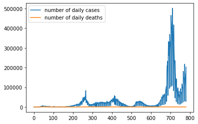

```python
import matplotlib.pyplot as plt
data = pd.read_csv('./data/data_covid_cases_deaths.csv')

data.plot()
plt.show()
```

**Subplots and plot of specific columns**

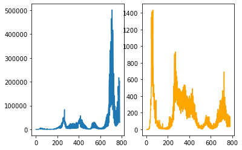

```python
import matplotlib.pyplot as plt
fig, axs = plt.subplots(nrows=1, ncols=2)
data['number of daily cases'].plot(ax=axs[0])
data['number of daily deaths'].plot(ax=axs[1], color='orange')
```

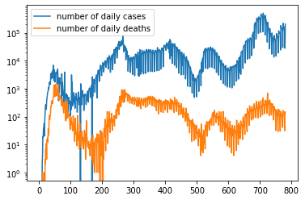

```python
import matplotlib.pyplot as plt
data = pd.read_csv('./data/data_covid_cases_deaths.csv')

data.plot()
plt.yscale('log')
plt.show()
```

```python
data['number of daily cases'].info()
```

```
<class 'pandas.core.series.Series'>
RangeIndex: 781 entries, 0 to 780
Series name: number of daily cases
Non-Null Count  Dtype
--------------  -----
781 non-null    int64
dtypes: int64(1)
memory usage: 6.2 KB
```

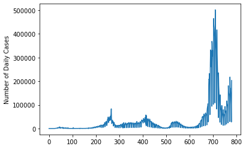

```python
data['number of daily cases'].plot()
plt.ylabel('Number of Daily Cases')
```

### Plotting specific columnts

- you can specify them with as above
- or path them throw `.columns`

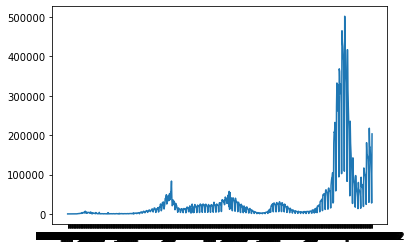

```python
import matplotlib.pyplot as plt
data = pd.read_csv('./data/data_covid_cases_deaths.csv')

plt.plot(data['date'], data['number of daily cases'])
plt.show()
```

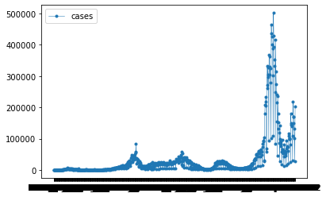

```python
plt.plot(data[data.columns[0]], data[data.columns[1]], linewidth = 0.5, label = 'cases', marker = '.')
plt.legend()
plt.show()
```

### Black area under the graph and splitting the picture into two separate pictures

- Black area is a consequency of two many labels that have form of the dates
  - A few dates must be specified manually
  - and then rotated
- `subplot()` method creates subplots

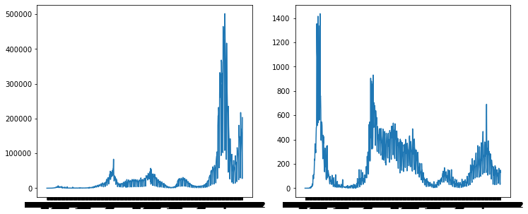

```python
fig, axs = plt.subplots(nrows=1, ncols=2, figsize=(12, 5))
axs[0].plot(data['date'], data['number of daily cases'])
axs[1].plot(data['date'], data['number of daily deaths'])
plt.show()
```

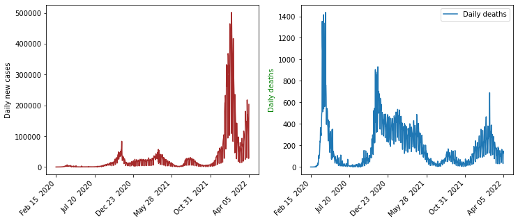

```python
fig, axs = plt.subplots(nrows=1, ncols=2, figsize=(12, 5))
d = data['date']
cases = data['number of daily cases']
deaths = data['number of daily deaths']
axs[0].plot(d, cases, color = 'brown')
num = 5
xlabel_my = []
for i in range(0, len(d), int(round(len(d)/num))):
    xlabel_my.append(d[i])
    #print(d[i])
axs[0].set_xticks([d[i] for i in range(0, len(d), int(round(len(d)/num)))])
axs[0].set_ylabel('Daily new cases')
#axs[0].set_xticklabels(xlabel_my, fontsize = 5)
axs[0].set_xticklabels(xlabel_my)

axs[1].plot(d, deaths, label = 'Daily deaths')
axs[1].set_xticks([d[i] for i in range(0, len(d), int(round(len(d)/num)))])
axs[1].set_ylabel('Daily deaths', color = 'green')
axs[1].legend()
fig.autofmt_xdate(rotation=45) # works if the labels are in the data format
plt.savefig('file_name.pdf')
```

```python
data_new = pd.read_csv('./data/data_covid_cases_deaths.csv', parse_dates=['date'], index_col=['date'])
data_new.info()
```

```
<class 'pandas.core.frame.DataFrame'>
DatetimeIndex: 781 entries, 2020-02-15 to 2022-04-05
Data columns (total 2 columns):
 #   Column                  Non-Null Count  Dtype
---  ------                  --------------  -----
 0   number of daily cases   781 non-null    int64
 1   number of daily deaths  781 non-null    int64
dtypes: int64(2)
memory usage: 18.3 KB
```

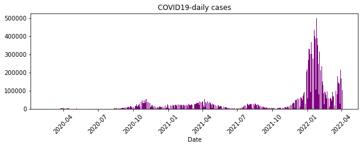

```python
# Create figure and plot space
fig, ax = plt.subplots(figsize=(10, 3))

# Add x-axis and y-axis
ax.bar(data_new.index.values,
        data_new['number of daily cases'],
        color='purple')

# Set title and labels for axes
ax.set(xlabel="Date",
       ylabel="",
       title="COVID19-daily cases")

# Rotate tick marks on x-axis
plt.setp(ax.get_xticklabels(), rotation=45)

plt.show()
```

## Excercises

- Use data from **covid_19_clean.csv**
- Read the table to variable `data`
- How many rows and columns are there?
- How many countries are in the table (be careful, the are replications)?
- What are the headers?
- Let `data` be the name of your table. Define

  ```
  data1 = data[data['Country/Region'] == 'Poland'].iloc[:365]
  ```

- find the mean number of deaths in the table `data1`
- plot the number of deaths vs. date
- plot the number of active cases vs. date
- repeat the last constructions for the country of your choice using the whole available range of dates